# Multidimensional Statistical Analysis

Lamyaa BOUZBIBA Alexandre POUPEAU Eloise JULIEN

```r
NAm2 = read.table("NAm2.txt", header = TRUE)
#NAm2
cont <- function(x)
{ if (x %in% c("Canada"))
  cont <-"NorthAmerica"
  else if (x %in% c("Guatemala","Mexico","Panama","CostaRica"))
  cont <-"CentralAmerica"
  else
  cont<-"SouthAmerica"
  return (factor(cont))
}
contID <- sapply(as.character(NAm2[,4]),FUN=cont)
library("class")
library("MASS")
```

#### a)

```r
labels <- rep (1:2, each = 494/2)
set = sample(labels, 494)
# continent + genetic markers
NAcont <- cbind(contID=contID,NAm2[,-(1:8)])
NAcont[,1] <- factor(NAcont[,1])
# we make our training phase using the elements which have its set value equal 1.
lda(contID ~ . , data = NAcont[, 1:1001], subset = (set == 1))
```

[output not shown]

Here, lda does not work because there are genetic markers with a variance of 0 so the intra_group covariance matrix is non-reversing and R cannot solve it. Actually, collinear variables should be removed.

#### b)

```r
withinvar <- apply(NAcont[(set==1),-1],FUN=function(x){tapply(x,NAcont[(set==1),1],FUN=var)},MARGIN=2)

bool <- as.logical(apply(withinvar,FUN=function(x){prod(x!=0)},MARGIN=2))

NAcont2 <- cbind(contID=contID,(NAm2[,-(1:8)])[,bool])

NAcont2[,1]<-factor(NAcont[,1])

classModel <- lda(contID ~ . , data = subset(NAcont2, set == 1))

#classModel
```

Instead of $5717$, there are $3136$ genetic markers remaining after removing those which variance is equal to zero.

#### c)

Now we predict the original populations of individuals who have not been trained.

```r
# Here we make our test phase using the elements which have its set value equal 2.
prediction <- predict(classModel, newdata = subset(NAcont2, set == 2))
#prediction$class
```

#### d)

```r
confusionMatrix <- table(subset(contID, set == 2), prediction$class)
confusionMatrix
```

```
                 NorthAmerica CentralAmerica SouthAmerica
  NorthAmerica             12              0           18
  CentralAmerica            0             33           55
  SouthAmerica              1              0          128
```

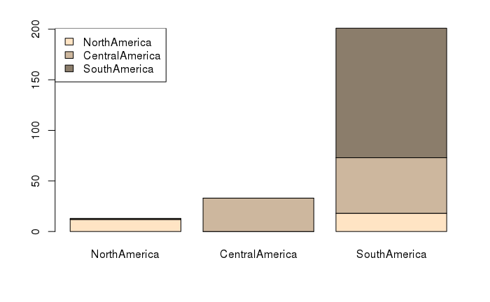

```r
barplot(confusionMatrix, col=c("bisque", "bisque3", "bisque4"))
legend("topleft", legend=c("NorthAmerica", "CentralAmerica", "SouthAmerica"), fill=c("bisque", "bisque3", "bisque4"))
```

With this barplot, we can see for instance that we predicted that 1 person is North American instead of South American. Moreover, we predicted that 55 people are South American instead of Central American, this the highest error.

#### e)

```r
rate <- 1-((sum(diag(confusionMatrix)))/sum(confusionMatrix))
sprintf("The rate of misclassified individuals is equal to %s .", rate)
```

```
[1] "The rate of misclassified individuals is equal to 0.299595141700405 ."
```

The classification error is equal to about 30% .

#### f)

```r
labels <- rep(1:13, each=13)
set = sample(labels, 494, replace=TRUE)
NAcont <- cbind(contID=contID,NAm2[,-(1:8)])
NAcont[,1] <- factor(NAcont[,1])
rate <- c(1:13)
for (i in 1:13){

  withinvar <- apply(NAcont[(set==i),-1],FUN=function(x){tapply(x,NAcont[(set==i),1],FUN=var)},MARGIN=2)
  bool <- as.logical(apply(withinvar,FUN=function(x){prod(x!=0)},MARGIN=2))
  NAcont2 <- cbind(contID=contID,(NAm2[,-(1:8)])[,bool])
  NAcont2[,1]<-factor(NAcont[,1])
  classModel <- lda(contID ~ . , data = subset(NAcont2, set != i))

  prediction <- predict(classModel, newdata = subset(NAcont2, set == i))

  confusionMatrix <- table(subset(contID, set == i), prediction$class)
  rate[i] <- 1-((sum(diag(confusionMatrix)))/sum(confusionMatrix))

}
```

[output not shown]

```r
sprintf("The rate of misclassified individuals is equal to %s .", mean(rate))
```

```
[1] "The rate of misclassified individuals is equal to 0.183506811286169 ."
```

With the 13-fold cross validation, the classification error is equal to about 18% .

To conclude, this cross validation is a good improvement to the method implemented in the previous question. Indeed, the classification error is equal to about 18% against 30% previously.